# Arbres de Décision

##### Les cercles de corrélation

Grâce à ces cercles de corrélation, nous pourrons voir les différentes variables corrélées

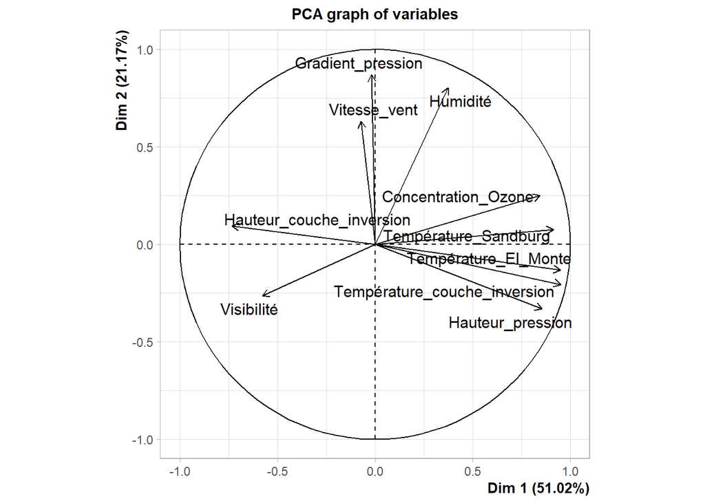

```r
plot(Ozone.acp,choix="var",axes=1:2)
```

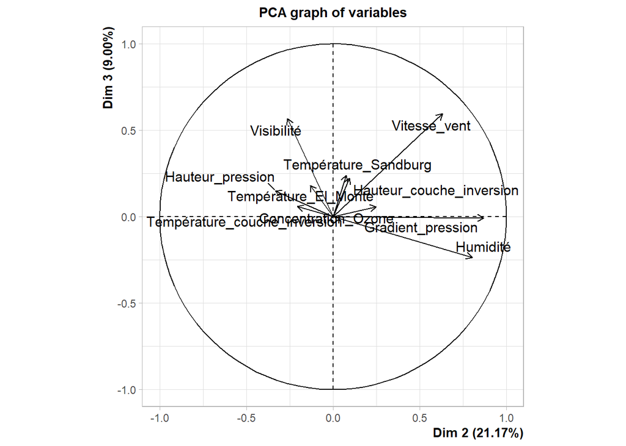

```r
plot(Ozone.acp,choix="var",axes=2:3)
```

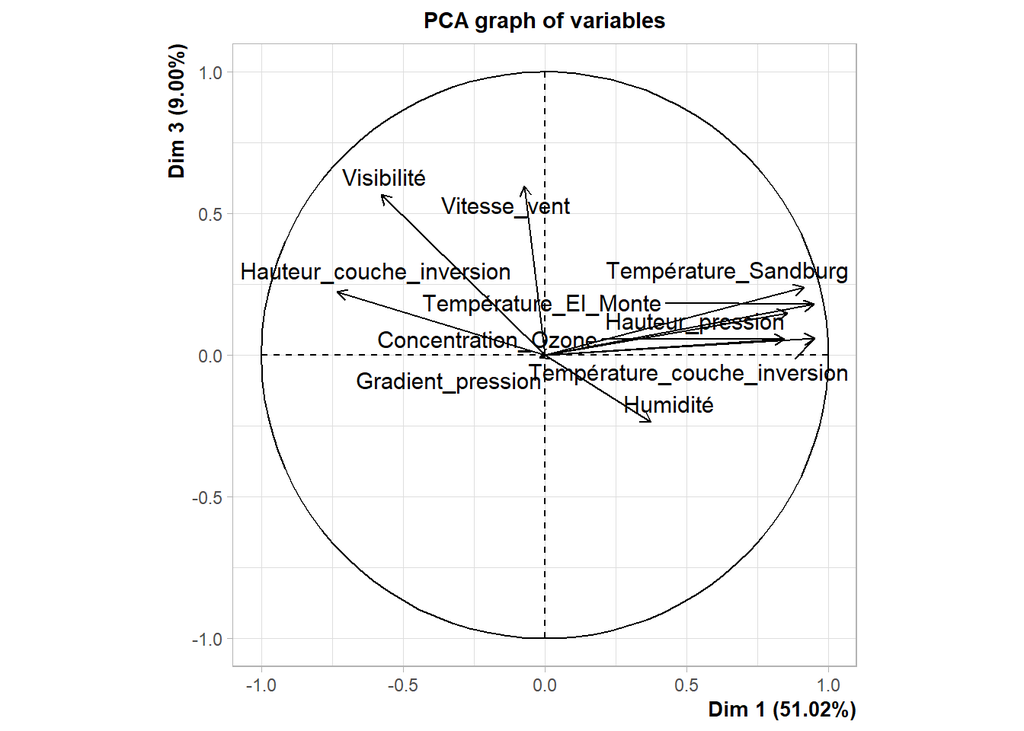

```r
plot(Ozone.acp,choix="var",axes=c(1,3))
```

## 3. Construction d’un arbre de régression CART sur les données de pollution

On va donc faire un arbre de régression afin de nous aider à identifier les facteurs prédictifs de la concentration d’Ozone. Notre arbre de régression de type CART (Classification And Regression Trees).

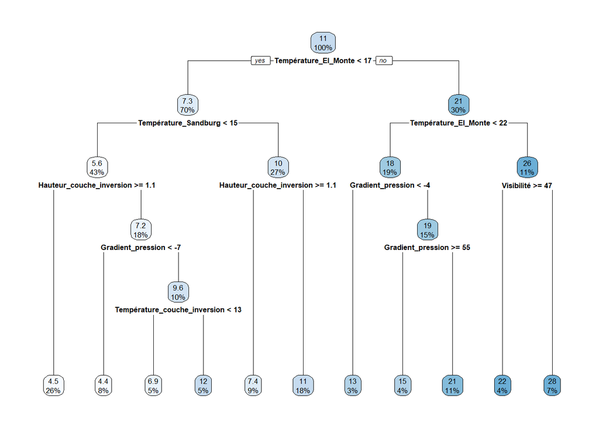

```r
library(rpart)
library(rpart.plot)
reg_cart = rpart(Concentration_Ozone~., data = var_num)
rpart.plot(reg_cart)
```

### Importance des variables

On regarde les valeurs de l’importance des variables de notre arbre de regression

```r
reg_cart$variable.importance
```

```
##         Température_El_Monte         Température_Sandburg
##                    9298.7804                    8389.5530
## Température_couche_inversion             Hauteur_pression
##                    6545.2924                    6048.3216
##                     Humidité     Hauteur_couche_inversion
##                    1728.4882                    1521.4629
##            Gradient_pression                   Visibilité
##                     810.4544                     368.7817
##                 Vitesse_vent
##                     122.1928
```

On crée la table correspondance de chaque variable avec son importance.

```r
importance = round(reg_cart$variable.importance)
varimp = tibble(Variable = names(importance), Importance = importance)
```

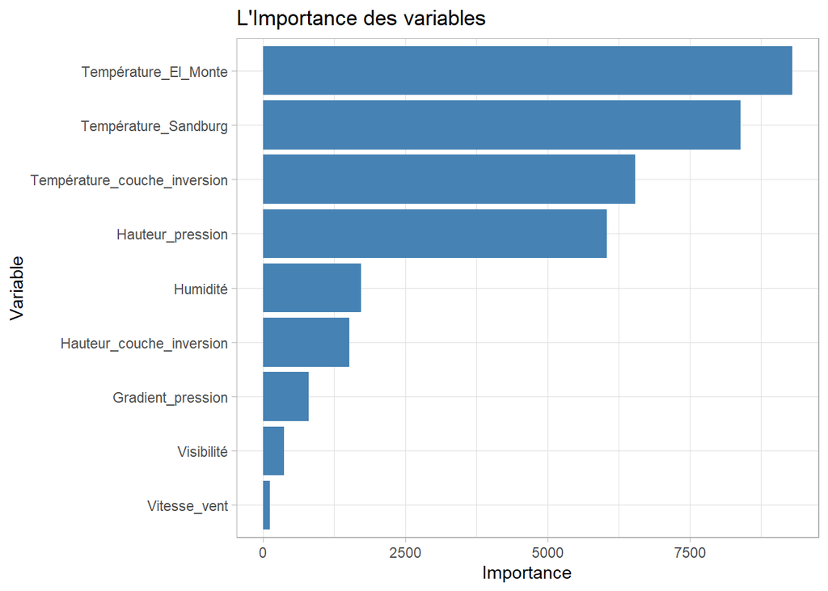

```r
varimp %>% ggplot(aes(fct_reorder(Variable, Importance), Importance))+
      geom_col(fill = "steelblue")+coord_flip()+
      labs(title = "L'Importance des variables",
           x = "Variable")+theme_light()
```